# **Instacart Grocery Basket Analysis - Project**

### **Part I**

**TABLE OF CONTENTS**

- Libraries
- Dataframes
- Data description
- Customer behavior by geographic region
  - Regional segmentation
  - Difference in spending habits between different regions
- Exclusion flag for low-activity customers
- Customer profiling
  - Profile classification
  - Profile categories
  - Profile category variable
  - Profile distribution
- Data aggregation
- Comparison of customer profiles by regions and departments
- Export

# Libraries

```python
import pandas as pd
import numpy as np
import os
import matplotlib.pyplot as plt
import seaborn as sns
import scipy
```

# Dataframes

```python
path = r'C:\Users\tomis\Documents\InstaCart Basket Analysis'
df = pd.read_pickle(os.path.join(path, '02 Data', 'Prepared Data', 'dataframe_combined.pkl'))
```

```python
df_dep = pd.read_pickle(os.path.join(path, '02 Data', 'Prepared Data', 'departments.pkl'))
```

**Note: Because of privacy and security issues, PII data like 'first_name' and 'last_name' is not included in this dataframe.**

# Data description

```python
# df dataframe (dataframe_combined) check

df.info()
```

```
<class 'pandas.core.frame.DataFrame'>
Int64Index: 32404859 entries, 0 to 32404858
Data columns (total 32 columns):
 #   Column                  Dtype
---  ------                  -----
 0   order_id                int32
 1   user_id                 int32
 2   order_number            int8
 3   orders_day_of_week      int8
 4   order_hour_of_day       int8
 5   days_since_prior_order  float32
 6   new_customer            bool
 7   product_id              int32
 8   add_to_cart_order       int32
 9   reordered               int8
```

[output cut: 24 more lines]

```python
df.shape
```

```
(32404859, 32)
```

```python
df.head()
```

|  | order_id | user_id | order_number | orders_day_of_week | order_hour_of_day | days_since_prior_order | new_customer | product_id | add_to_cart_order | reordered | ... | spender_type | orders_median | frequency_flag | gender | state | age | date_joined | dependants_number | family_status | income |
| --- | --- | --- | --- | --- | --- | --- | --- | --- | --- | --- | --- | --- | --- | --- | --- | --- | --- | --- | --- | --- | --- |
| 0 | 2539329 | 1 | 1 | 2 | 8 | NaN | True | 196 | 1 | 0 | ... | Low spender | 20.5 | Non-frequent customer | Female | Alabama | 31 | 2/17/2019 | 3 | married | 40423 |
| 1 | 2398795 | 1 | 2 | 3 | 7 | 15.0 | False | 196 | 1 | 1 | ... | Low spender | 20.5 | Non-frequent customer | Female | Alabama | 31 | 2/17/2019 | 3 | married | 40423 |
| 2 | 473747 | 1 | 3 | 3 | 12 | 21.0 | False | 196 | 1 | 1 | ... | Low spender | 20.5 | Non-frequent customer | Female | Alabama | 31 | 2/17/2019 | 3 | married | 40423 |
| 3 | 2254736 | 1 | 4 | 4 | 7 | 29.0 | False | 196 | 1 | 1 | ... | Low spender | 20.5 | Non-frequent customer | Female | Alabama | 31 | 2/17/2019 | 3 | married | 40423 |
| 4 | 431534 | 1 | 5 | 4 | 15 | 28.0 | False | 196 | 1 | 1 | ... | Low spender | 20.5 | Non-frequent customer | Female | Alabama | 31 | 2/17/2019 | 3 | married | 40423 |

5 rows × 32 columns

```python
df.tail()
```

|  | order_id | user_id | order_number | orders_day_of_week | order_hour_of_day | days_since_prior_order | new_customer | product_id | add_to_cart_order | reordered | ... | spender_type | orders_median | frequency_flag | gender | state | age | date_joined | dependants_number | family_status | income |
| --- | --- | --- | --- | --- | --- | --- | --- | --- | --- | --- | --- | --- | --- | --- | --- | --- | --- | --- | --- | --- | --- |
| 32404854 | 156685 | 106143 | 26 | 4 | 23 | 5.0 | False | 19675 | 1 | 1 | ... | High spender | 7.0 | Frequent customer | Male | Hawaii | 25 | 5/26/2017 | 0 | single | 53755 |
| 32404855 | 484769 | 66343 | 1 | 6 | 11 | NaN | True | 47210 | 1 | 0 | ... | Low spender | 30.0 | Non-frequent customer | Female | Tennessee | 22 | 9/12/2017 | 3 | married | 46151 |
| 32404856 | 1561557 | 66343 | 2 | 1 | 11 | 30.0 | False | 47210 | 1 | 1 | ... | Low spender | 30.0 | Non-frequent customer | Female | Tennessee | 22 | 9/12/2017 | 3 | married | 46151 |
| 32404857 | 276317 | 66343 | 3 | 6 | 15 | 19.0 | False | 47210 | 1 | 1 | ... | Low spender | 30.0 | Non-frequent customer | Female | Tennessee | 22 | 9/12/2017 | 3 | married | 46151 |
| 32404858 | 2922475 | 66343 | 4 | 1 | 12 | 30.0 | False | 47210 | 1 | 1 | ... | Low spender | 30.0 | Non-frequent customer | Female | Tennessee | 22 | 9/12/2017 | 3 | married | 46151 |

5 rows × 32 columns

```python
# df_dep dataframe (departments) check

df_dep.shape
```

```
(21, 1)
```

```python
df_dep.head()
```

| department_id | department |
| --- | --- |
| 1 | frozen |
| 2 | other |
| 3 | bakery |
| 4 | produce |
| 5 | alcohol |

```python
df_dep.info()
```

```
<class 'pandas.core.frame.DataFrame'>
Index: 21 entries, 1 to 21
Data columns (total 1 columns):
 #   Column      Non-Null Count  Dtype
---  ------      --------------  -----
 0   department  21 non-null     object
dtypes: object(1)
memory usage: 336.0+ bytes
```

# Customer behavior by geographic region

### Regional segmentation

```python
# creating the 'region' column

reg = []
for x in df['state']:
    if x in ['Maine', 'New Hampshire', 'Vermont', 'Massachusetts', 'Rhode Island', 'Connecticut', 'New York', 'Pennsylvania', 'New Jersey']:
        reg.append('Northeast')
    elif x in ['Wisconsin', 'Michigan', 'Illinois', 'Indiana', 'Ohio', 'North Dakota', 'South Dakota', 'Nebraska', 'Kansas', 'Minnesota', 'Iowa', 'Missouri']:
        reg.append('Midwest')
    elif x in ['Delaware', 'Maryland', 'District of Columbia', 'Virginia', 'West Virginia', 'North Carolina', 'South Carolina', 'Georgia', 'Florida', 'Kentucky', 'Tennessee', 'Mississippi', 'Alabama', 'Oklahoma', 'Texas', 'Arkansas', 'Louisiana']:
        reg.append('South')
    elif x in ['Idaho', 'Montana', 'Wyoming', 'Nevada', 'Utah', 'Colorado', 'Arizona', 'New Mexico', 'Alaska', 'Washington', 'Oregon', 'California', 'Hawaii']:
        reg.append('West')
    else:
        reg.append('Unknown')
```

```python
# adding the 'region' column to the dataframe

df['region'] = reg
```

### Difference in spending habits between different regions

```python
tab_reg = pd.crosstab(df['region'], df['spender_type'], dropna=False)
print(tab_reg)
```

```
spender_type  High spender  Low spender
region
Midwest             155975      7441350
Northeast           108225      5614511
South               209691     10582194
West                160354      8132559
```

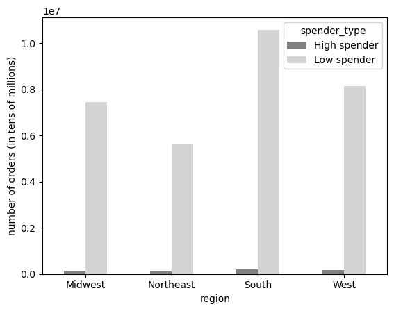

```python
bar_reg = tab_reg.plot.bar(xlabel = 'region', ylabel = 'number of orders (in tens of millions)', rot = 'horizontal', color = ['gray', 'lightgray'])
```

```python
df.groupby('region').agg({'prices':['mean']})
```

| region | prices mean |
| --- | --- |
| Midwest | 7.792584 |
| Northeast | 7.782409 |
| South | 7.794918 |
| West | 7.790356 |

```python
df.groupby('region').agg({'days_since_prior_order':['mean']})
```

| region | days_since_prior_order mean |
| --- | --- |
| Midwest | 11.181836 |
| Northeast | 11.075769 |
| South | 11.108108 |
| West | 11.047195 |

**Regional differences in spending habits are small - average price of all orders is very similar across the regions, as well as activity and the high/low spender ratio.**

# Exclusion flag for low-activity customers

```python
# low-activity customers = 0

df.loc[df['max_order'] < 5, 'exclusion_flag'] = '0'
df.loc[df['max_order'] >= 5, 'exclusion_flag'] = '1'
```

```python
df['exclusion_flag'].value_counts()
```

```
1    30964564
0     1440295
Name: exclusion_flag, dtype: int64
```

```python
# low-activity customers - subset

low_activity_cust = df[df['exclusion_flag'] == '0']
```

```python
# low-activity customers - export

low_activity_cust.to_pickle(os.path.join(path, '02 Data', 'Prepared Data', 'low_activity_customers.pkl'))
```

```python
# overwriting the dataframe - no low-activity customers

df = df[df['exclusion_flag'] == '1']
```

```python
df.shape
```

```
(30964564, 34)
```

# Customer profiling

### Profile classification

by age:

- **young adult** - 18 - 30 years
- **middle-aged adult** -31 - 60 years
- **older adult** - 61 years and above

by marital status:

- **single** - a person who is either not married, is divorced , is widowed or lives with parent/s or sibling/s.
- **married** - a legally married person

by family status:

- **nonparent** - a person without children or dependants
- **parent** - a person with any number of children or dependants

by income:

- **low income** - less than $52,200
- **middle income** - \$52,200 - \\$156,600
- **upper income** - \$156,600 or more

Custom profiles:

### Profile categories

| category | age | marital status | family status | income |
| --- | --- | --- | --- | --- |
| 01 | young | single | nonparent | low |
| 02 | young | single | nonparent | middle |
| 03 | young | single | nonparent | upper |
| 04 | young | single | parent | low |
| 05 | young | single | parent | middle |
| 06 | young | single | parent | upper |
| 07 | young | married | nonparent | low |
| 08 | young | married | nonparent | middle |
| 09 | young | married | nonparent | upper |
| 10 | young | married | parent | low |
| 11 | young | married | parent | middle |
| 12 | young | married | parent | upper |
| 13 | middle-aged | single | nonparent | low |
| 14 | middle-aged | single | nonparent | middle |
| 15 | middle-aged | single | nonparent | upper |
| 16 | middle-aged | single | parent | low |
| 17 | middle-aged | single | parent | middle |
| 18 | middle-aged | single | parent | upper |
| 19 | middle-aged | married | nonparent | low |
| 20 | middle-aged | married | nonparent | middle |
| 21 | middle-aged | married | nonparent | upper |
| 22 | middle-aged | married | parent | low |
| 23 | middle-aged | married | parent | middle |
| 24 | middle-aged | married | parent | upper |
| 25 | older | single | nonparent | low |
| 26 | older | single | nonparent | middle |
| 27 | older | single | nonparent | upper |
| 28 | older | single | parent | low |
| 29 | older | single | parent | middle |
| 30 | older | single | parent | upper |
| 31 | older | married | nonparent | low |
| 32 | older | married | nonparent | middle |
| 33 | older | married | nonparent | upper |
| 34 | older | married | parent | low |
| 35 | older | married | parent | middle |
| 36 | older | married | parent | upper |

### Profile category variable

##### Age

```python
df.loc[df['age'] <= 30, 'age_category'] = 'young adult'
```

```python
df.loc[(df['age'] > 30) & (df['age'] <= 60), 'age_category'] = 'middle-aged adult'
```

```python
df.loc[df['age'] > 60, 'age_category'] = 'older adult'
```

##### Marital status

```python
df.loc[df['family_status'] == 'married', 'marital_category'] = 'married'
```

```python
df.loc[df['family_status'] != 'married', 'marital_category'] = 'single'
```

##### Family status

```python
df.loc[df['dependants_number'] == 0, 'family_category'] = 'nonparent'
```

```python
df.loc[df['dependants_number'] != 0, 'family_category'] = 'parent'
```

##### Income

```python
df.loc[df['income'] < 52200, 'income_category'] = 'low income'
```

```python
df.loc[(df['income'] >= 52200) & (df['income'] < 156600), 'income_category'] = 'middle income'
```

```python
df.loc[df['income'] >= 156600, 'income_category'] = 'upper income'
```

##### Profile category

```python
df.loc[(df['age_category'] == 'young adult') & (df['marital_category'] == 'single') & (df['family_category'] == 'nonparent') & (df['income_category'] == 'low income'), 'profile_category'] = '01'
```

```python
df.loc[(df['age_category'] == 'young adult') & (df['marital_category'] == 'single') & (df['family_category'] == 'nonparent') & (df['income_category'] == 'middle income'), 'profile_category'] = '02'
```

```python
df.loc[(df['age_category'] == 'young adult') & (df['marital_category'] == 'single') & (df['family_category'] == 'nonparent') & (df['income_category'] == 'upper income'), 'profile_category'] = '03'
```

```python
df.loc[(df['age_category'] == 'young adult') & (df['marital_category'] == 'single') & (df['family_category'] == 'parent') & (df['income_category'] == 'low income'), 'profile_category'] = '04'
```

```python
df.loc[(df['age_category'] == 'young adult') & (df['marital_category'] == 'single') & (df['family_category'] == 'parent') & (df['income_category'] == 'middle income'), 'profile_category'] = '05'
```

```python
df.loc[(df['age_category'] == 'young adult') & (df['marital_category'] == 'single') & (df['family_category'] == 'parent') & (df['income_category'] == 'upper income'), 'profile_category'] = '06'
```

```python
df.loc[(df['age_category'] == 'young adult') & (df['marital_category'] == 'married') & (df['family_category'] == 'nonparent') & (df['income_category'] == 'low income'), 'profile_category'] = '07'
```

```python
df.loc[(df['age_category'] == 'young adult') & (df['marital_category'] == 'married') & (df['family_category'] == 'nonparent') & (df['income_category'] == 'middle income'), 'profile_category'] = '08'
```

```python
df.loc[(df['age_category'] == 'young adult') & (df['marital_category'] == 'married') & (df['family_category'] == 'nonparent') & (df['income_category'] == 'upper income'), 'profile_category'] = '09'
```

```python
df.loc[(df['age_category'] == 'young adult') & (df['marital_category'] == 'married') & (df['family_category'] == 'parent') & (df['income_category'] == 'low income'), 'profile_category'] = '10'
```

```python
df.loc[(df['age_category'] == 'young adult') & (df['marital_category'] == 'married') & (df['family_category'] == 'parent') & (df['income_category'] == 'middle income'), 'profile_category'] = '11'
```

```python
df.loc[(df['age_category'] == 'young adult') & (df['marital_category'] == 'married') & (df['family_category'] == 'parent') & (df['income_category'] == 'upper income'), 'profile_category'] = '12'
```

```python
df.loc[(df['age_category'] == 'middle-aged adult') & (df['marital_category'] == 'single') & (df['family_category'] == 'nonparent') & (df['income_category'] == 'low income'), 'profile_category'] = '13'
```

```python
df.loc[(df['age_category'] == 'middle-aged adult') & (df['marital_category'] == 'single') & (df['family_category'] == 'nonparent') & (df['income_category'] == 'middle income'), 'profile_category'] = '14'
```

```python
df.loc[(df['age_category'] == 'middle-aged adult') & (df['marital_category'] == 'single') & (df['family_category'] == 'nonparent') & (df['income_category'] == 'upper income'), 'profile_category'] = '15'
```

```python
df.loc[(df['age_category'] == 'middle-aged adult') & (df['marital_category'] == 'single') & (df['family_category'] == 'parent') & (df['income_category'] == 'low income'), 'profile_category'] = '16'
```

```python
df.loc[(df['age_category'] == 'middle-aged adult') & (df['marital_category'] == 'single') & (df['family_category'] == 'parent') & (df['income_category'] == 'middle income'), 'profile_category'] = '17'
```

```python
df.loc[(df['age_category'] == 'middle-aged adult') & (df['marital_category'] == 'single') & (df['family_category'] == 'parent') & (df['income_category'] == 'upper income'), 'profile_category'] = '18'
```

```python
df.loc[(df['age_category'] == 'middle-aged adult') & (df['marital_category'] == 'married') & (df['family_category'] == 'nonparent') & (df['income_category'] == 'low income'), 'profile_category'] = '19'
```

```python
df.loc[(df['age_category'] == 'middle-aged adult') & (df['marital_category'] == 'married') & (df['family_category'] == 'nonparent') & (df['income_category'] == 'middle income'), 'profile_category'] = '20'
```

```python
df.loc[(df['age_category'] == 'middle-aged adult') & (df['marital_category'] == 'married') & (df['family_category'] == 'nonparent') & (df['income_category'] == 'upper income'), 'profile_category'] = '21'
```

```python
df.loc[(df['age_category'] == 'middle-aged adult') & (df['marital_category'] == 'married') & (df['family_category'] == 'parent') & (df['income_category'] == 'low income'), 'profile_category'] = '22'
```

```python
df.loc[(df['age_category'] == 'middle-aged adult') & (df['marital_category'] == 'married') & (df['family_category'] == 'parent') & (df['income_category'] == 'middle income'), 'profile_category'] = '23'
```

```python
df.loc[(df['age_category'] == 'middle-aged adult') & (df['marital_category'] == 'married') & (df['family_category'] == 'parent') & (df['income_category'] == 'upper income'), 'profile_category'] = '24'
```

```python
df.loc[(df['age_category'] == 'older adult') & (df['marital_category'] == 'single') & (df['family_category'] == 'nonparent') & (df['income_category'] == 'low income'), 'profile_category'] = '25'
```

```python
df.loc[(df['age_category'] == 'older adult') & (df['marital_category'] == 'single') & (df['family_category'] == 'nonparent') & (df['income_category'] == 'middle income'), 'profile_category'] = '26'
```

```python
df.loc[(df['age_category'] == 'older adult') & (df['marital_category'] == 'single') & (df['family_category'] == 'nonparent') & (df['income_category'] == 'upper income'), 'profile_category'] = '27'
```

```python
df.loc[(df['age_category'] == 'older adult') & (df['marital_category'] == 'single') & (df['family_category'] == 'parent') & (df['income_category'] == 'low income'), 'profile_category'] = '28'
```

```python
df.loc[(df['age_category'] == 'older adult') & (df['marital_category'] == 'single') & (df['family_category'] == 'parent') & (df['income_category'] == 'middle income'), 'profile_category'] = '29'
```

```python
df.loc[(df['age_category'] == 'older adult') & (df['marital_category'] == 'single') & (df['family_category'] == 'parent') & (df['income_category'] == 'upper income'), 'profile_category'] = '30'
```

```python
df.loc[(df['age_category'] == 'older adult') & (df['marital_category'] == 'married') & (df['family_category'] == 'nonparent') & (df['income_category'] == 'low income'), 'profile_category'] = '31'
```

```python
df.loc[(df['age_category'] == 'older adult') & (df['marital_category'] == 'married') & (df['family_category'] == 'nonparent') & (df['income_category'] == 'middle income'), 'profile_category'] = '32'
```

```python
df.loc[(df['age_category'] == 'older adult') & (df['marital_category'] == 'married') & (df['family_category'] == 'nonparent') & (df['income_category'] == 'upper income'), 'profile_category'] = '33'
```

```python
df.loc[(df['age_category'] == 'older adult') & (df['marital_category'] == 'married') & (df['family_category'] == 'parent') & (df['income_category'] == 'low income'), 'profile_category'] = '34'
```

```python
df.loc[(df['age_category'] == 'older adult') & (df['marital_category'] == 'married') & (df['family_category'] == 'parent') & (df['income_category'] == 'middle income'), 'profile_category'] = '35'
```

```python
df.loc[(df['age_category'] == 'older adult') & (df['marital_category'] == 'married') & (df['family_category'] == 'parent') & (df['income_category'] == 'upper income'), 'profile_category'] = '36'
```

### Profile distribution

```python
df['profile_category'].value_counts()
```

```
23    8643325
35    5906552
14    2858544
11    2664185
26    1974029
02    1277056
22    1276865
05    1217642
24     994319
36     993814
34     679140
10     557425
13     424843
15     349821
27     340631
01     284481
04     250513
25     218441
12      28086
06      13017
03      11835
Name: profile_category, dtype: int64
```

All our customers fall into one of 21 out of total of 36 profile categories defined in the 'Profile category' section.  
None of our customers fall into categories:

- 07 - young, married, nonparent, low income
- 08 - young, married, nonparent, middle income
- 09 - young, married, nonparent, upper income
- 16 - middle-aged, single, parent, low income
- 17 - middle-aged, single, parent, middle income
- 18 - middle-aged, single, parent, upper income
- 19 - middle-aged, married, nonparent, low income
- 20 - middle-aged, married, nonparent, middle income
- 21 - middle-aged, married, nonparent, upper income
- 28 - older, single, parent, low income
- 29 - older, single, parent, middle income
- 30 - older, single, parent, upper income
- 31 - older, married, nonparent, low income
- 32 - older, married, nonparent, middle income
- 33 - older, married, nonparent, upper income

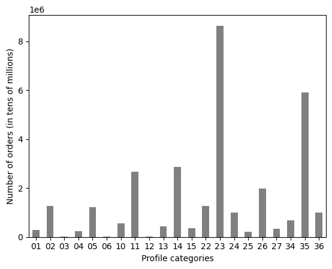

```python
bar_profile = df['profile_category'].value_counts().sort_index().plot.bar(color= 'gray', xlabel = 'Profile categories', ylabel = 'Number of orders (in tens of millions)', rot='horizontal')
```

#### Most popular order time per profile category

1st Shift = 9am - 5pm  
2nd Shift = 5pm - 1am  
3rd Shift = 1am - 9am

```python
# shift_flag

df.loc[df['order_hour_of_day'].isin([9, 10, 11, 12, 13, 14, 15, 16]), 'work_shift'] = 'I. shift'
df.loc[df['order_hour_of_day'].isin([17, 18, 19, 20, 21, 22, 23, 0]), 'work_shift'] = 'II. shift'
df.loc[df['order_hour_of_day'].isin([1, 2, 3, 4, 5, 6, 7, 8]), 'work_shift'] = 'III. shift'
```

```python
tab_time = pd.crosstab(df['profile_category'], df['work_shift'], dropna = False)
```

```python
# order times per profile category

tab_time
```

| work_shift profile_category | I. shift | II. shift | III. shift |
| --- | --- | --- | --- |
| 01 | 192430 | 63369 | 28682 |
| 02 | 825454 | 321430 | 130172 |
| 03 | 7958 | 2730 | 1147 |
| 04 | 167962 | 59011 | 23540 |
| 05 | 786744 | 303823 | 127075 |
| 06 | 9400 | 2598 | 1019 |
| 10 | 377330 | 127422 | 52673 |
| 11 | 1736077 | 652546 | 275562 |
| 12 | 18219 | 6944 | 2923 |
| 13 | 285839 | 94752 | 44252 |
| 14 | 1849318 | 716216 | 293010 |
| 15 | 225802 | 85858 | 38161 |
| 22 | 858067 | 293791 | 125007 |
| 23 | 5614480 | 2151050 | 877795 |
| 24 | 642561 | 248700 | 103058 |
| 25 | 148080 | 48057 | 22304 |
| 26 | 1280236 | 490671 | 203122 |
| 27 | 220482 | 84784 | 35365 |
| 34 | 453209 | 158112 | 67819 |
| 35 | 3838107 | 1460031 | 608414 |
| 36 | 643101 | 249188 | 101525 |

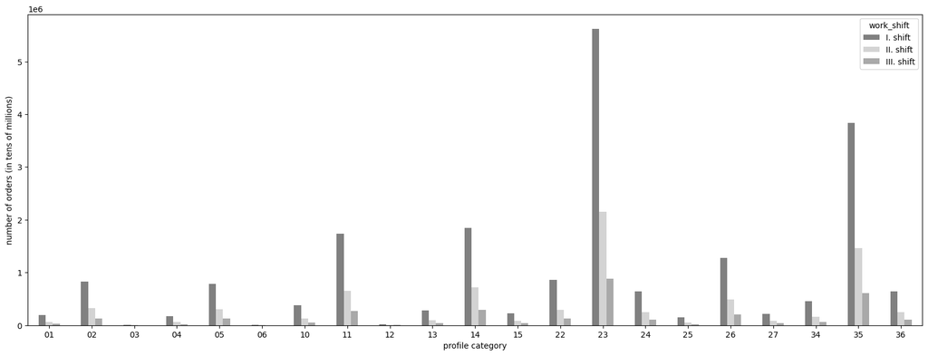

```python
bar_time = tab_time.plot(kind = 'bar', color = ['gray', 'lightgray', 'darkgray'], figsize = (20,7), rot = 'horizontal', xlabel = 'profile category', ylabel = 'number of orders (in tens of millions)')
```

# Data aggregation

#### By usage frequency

```python
df.groupby('profile_category').agg({'days_since_prior_order': ['mean', 'min', 'max']})
```

| profile_category | days_since_prior_order mean | days_since_prior_order min | days_since_prior_order max |
| --- | --- | --- | --- |
| 01 | 11.132957 | 0.0 | 30.0 |
| 02 | 10.904235 | 0.0 | 30.0 |
| 03 | 11.090675 | 0.0 | 30.0 |
| 04 | 11.284382 | 0.0 | 30.0 |
| 05 | 10.655309 | 0.0 | 30.0 |
| 06 | 9.499601 | 0.0 | 30.0 |
| 10 | 11.134749 | 0.0 | 30.0 |
| 11 | 10.765913 | 0.0 | 30.0 |
| 12 | 10.487613 | 0.0 | 30.0 |
| 13 | 10.989375 | 0.0 | 30.0 |
| 14 | 10.769935 | 0.0 | 30.0 |
| 15 | 10.406620 | 0.0 | 30.0 |
| 22 | 11.200998 | 0.0 | 30.0 |
| 23 | 10.773066 | 0.0 | 30.0 |
| 24 | 10.823698 | 0.0 | 30.0 |
| 25 | 11.179020 | 0.0 | 30.0 |
| 26 | 10.713081 | 0.0 | 30.0 |
| 27 | 10.623575 | 0.0 | 30.0 |
| 34 | 11.127441 | 0.0 | 30.0 |
| 35 | 10.804039 | 0.0 | 30.0 |
| 36 | 10.621200 | 0.0 | 30.0 |

#### By expenditure

```python
df.groupby('profile_category').agg({'prices': ['mean', 'min', 'max', 'sum']})
```

| profile_category | prices mean | prices min | prices max | prices sum |
| --- | --- | --- | --- | --- |
| 01 | 6.996967 | 1.0 | 25.0 | 1.990504e+06 |
| 02 | 7.945729 | 1.0 | 25.0 | 1.014616e+07 |
| 03 | 7.715315 | 1.0 | 25.0 | 9.052380e+04 |
| 04 | 7.019078 | 1.0 | 25.0 | 1.758370e+06 |
| 05 | 7.959813 | 1.0 | 25.0 | 9.691589e+06 |
| 06 | 7.950671 | 1.0 | 25.0 | 1.025716e+05 |
| 10 | 6.987693 | 1.0 | 25.0 | 3.895115e+06 |
| 11 | 7.942319 | 1.0 | 25.0 | 2.115769e+07 |
| 12 | 7.759674 | 1.0 | 25.0 | 2.152068e+05 |
| 13 | 6.745749 | 1.0 | 25.0 | 2.865884e+06 |
| 14 | 7.929829 | 1.0 | 25.0 | 2.266676e+07 |
| 15 | 7.918361 | 1.0 | 25.0 | 2.766960e+06 |
| 22 | 6.753661 | 1.0 | 25.0 | 8.623513e+06 |
| 23 | 7.927244 | 1.0 | 25.0 | 6.851401e+07 |
| 24 | 7.937580 | 1.0 | 25.0 | 7.882540e+06 |
| 25 | 6.523318 | 1.0 | 25.0 | 1.424960e+06 |
| 26 | 7.917624 | 1.0 | 25.0 | 1.562882e+07 |
| 27 | 7.931087 | 1.0 | 25.0 | 2.698925e+06 |
| 34 | 6.509172 | 1.0 | 25.0 | 4.420640e+06 |
| 35 | 7.916582 | 1.0 | 25.0 | 4.675770e+07 |
| 36 | 7.952266 | 1.0 | 25.0 | 7.895797e+06 |

# Comparison of customer profiles by regions and departments

```python
df.groupby('region').agg({'user_id': ['count']})
```

| region | user_id count |
| --- | --- |
| Midwest | 7261513 |
| Northeast | 5464685 |
| South | 10311139 |
| West | 7927227 |

```python
tab_profile = df.groupby(['profile_category', 'department_id', 'region']).agg({'prices': ['mean'], 'days_since_prior_order': ['mean']})
```

```python
tab_profile.to_clipboard()
```

```python
df.groupby(['age_category', 'department_id', 'region']).agg({'order_id': ['count']})
```

[output not shown]

#### Number of orders per department among different age groups

```python
tab_dep = pd.crosstab(df['age_category'], df['department_id'], dropna = False)
```

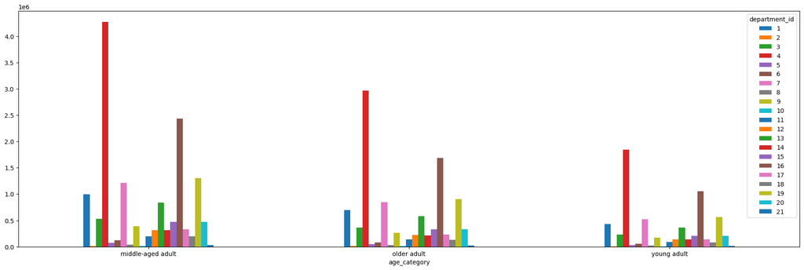

```python
age_dep = tab_dep.plot(kind = 'bar', figsize = (23,7), rot = 'horizontal')
```

# Export

```python
df.info()
```

```
<class 'pandas.core.frame.DataFrame'>
Int64Index: 30964564 entries, 0 to 32404854
Data columns (total 40 columns):
 #   Column                  Dtype
---  ------                  -----
 0   order_id                int32
 1   user_id                 int32
 2   order_number            int8
 3   orders_day_of_week      int8
 4   order_hour_of_day       int8
 5   days_since_prior_order  float32
 6   new_customer            bool
 7   product_id              int32
 8   add_to_cart_order       int32
 9   reordered               int8
```

[output cut: 32 more lines]

```python
# changing datatypes

df['age'] = df['age'].astype('int8')
df['dependants_number'] = df['dependants_number'].astype('int8')
df['income'] = df['income'].astype('int32')
```

```python
# exporting visualizations

bar_reg.figure.savefig(os.path.join(path, '04 Analysis','Visualizations', 'regional spender types.png'))
```

```python
bar_profile.figure.savefig(os.path.join(path, '04 Analysis','Visualizations', 'profile distribution.png'))
```

```python
bar_time.figure.savefig(os.path.join(path, '04 Analysis','Visualizations', 'order time popularity.png'))
```

```python
age_dep.figure.savefig(os.path.join(path, '04 Analysis','Visualizations', 'departments popularity.png'))
```

```python
# exporting dataframes

df.to_pickle(os.path.join(path, '02 Data', 'Prepared Data', 'dataframe_combined.pkl'))
```

```python
df_dep.to_pickle(os.path.join(path, '02 Data', 'Prepared Data', 'departments.pkl'))
```